# So you’ve been asked to make a reprex

Jesse M

2018-02-12

## Introduction

If you’ve found yourself here, you’ve probably been asked to create a **re**producible **ex**ample, or [reprex](https://www.tidyverse.org/help/), in response to a question you asked on the [RStudio Community Site](https://community.rstudio.com/). This post provides a cursory overview of both creating a reprex as well as how to *share* your reprex on the RStudio Community site.

## A brief reprex “how to”

1. [Install the development version of reprex from GitHub](https://github.com/tidyverse/reprex) and then load the `reprex` package
2. Highlight the code *and associated packages*, as indicated by `library(package_name)`, like so:

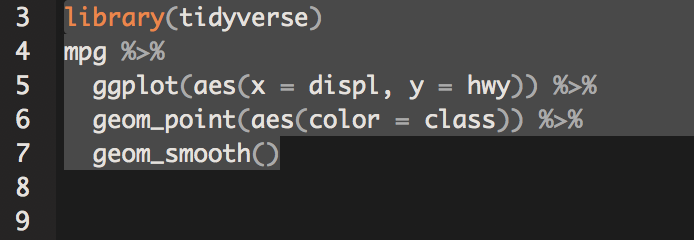

3. Copy the highlighted code by pressing Ctrl/Cmd + c
4. In the [console](http://r4ds.had.co.nz/workflow-scripts.html) type `reprex()` and hit Enter/Return
5. Everything that you need to post a reprex is now automatically stored on your clipboard!

## Posting to community.rstudio.com

Remember that as soon as you run `reprex()` in the console, everything you need to share your reprex has been stored on your clipboard, and you do not need to take any additional steps to getting a reprex ready for posting!

Navigate to [community.rstudio.com](https://community.rstudio.com/) and create a new post. Within the text editor, paste (Ctrl/Cmd + v) your reprex output (which has already been stored on your clipboard) and add any necessary commentary to help community members answer your question, as follows:

[figure not shown]

## Why you should reprex

Writing a reprex for the problem you’re encountering is one of the best ways to demonstrate that you are being considerate of the people who are going to help you solve the error(s) in your code. You don’t *have* to write a reprex, but when you do, you’re saying “I’m having trouble with something, and I want to demonstrate that I value your time and expertise by creating a reprex. I know that creating a reprex will make it a little bit easier for you to help me, and I want to help you help me.”

Reprexes are significantly easier to read, as well as copy and paste. This means that the people helping you solve your error(s) are going to spend less time:

1. Going back and forth in the forums asking for more information
2. Trying to replicate the exact error(s) you’re dealing with
3. Interpreting a jumble of non-formatted code

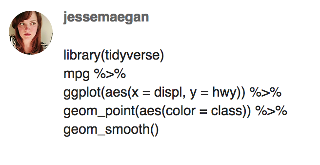

*non-formatted R code (above) vs. formatted R code (below)*

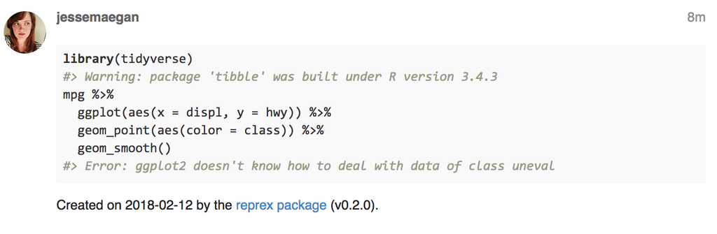

This means they’re going to have more time to do one thing: **help you**

## Still not convinced a reprex is necessary?

No one can force you to make a reprex, but they can decide not to answer your question when you don’t provide a reprex.

### The cake analogy

*Thanks to [Larie](https://twitter.com/lariebyrd) for this one!*

Imagine that you’ve made a cake, and for some reason it’s turned out absolutely awful - we’re talking completely inedible. Asking a question *without* a reprex is like asking, “Why didn’t my cake turn out right?” – there are hundreds of possible answers to that question, and it’s going to take a long time to narrow in on the exact cause for your inedible cake creation.

Asking a question *with* a reprex is like asking, “My cake didn’t turn out, and here’s the recipe I used and the steps that I followed. Where did I go wrong?” Using this method is going to significantly increase the likelihood of you getting a helpful response, faster!

### The lost at sea analogy

*Thanks to [Charlotte](https://twitter.com/CVWickham) for this one!*

“If you are marooned on a desert island, it’s like the difference between putting SOS on your message in a bottle, and putting SOS *and* your GPS coordinates on your message in a bottle.”

### Neither of these analogies working for you?

[Additional analogies](https://twitter.com/kierisi/status/963191049060528129) can be found here - and feel free to revive the thread with your own!

## So this post didn’t answer *all* of your reprex questions?

- [What to do if your reprex() requires data](https://community.rstudio.com/t/best-practices-how-to-prepare-your-own-data-for-use-in-a-reprex-if-you-can-t-or-don-t-know-how-to-reproduce-a-problem-with-a-built-in-dataset/5346)

And a million thanks to [Mara](https://twitter.com/dataandme) for collecting all the reprex and question-asking resources you could ever need:

- [reprex package](http://reprex.tidyverse.org/)
- [reprex GitHub](https://github.com/tidyverse/reprex)
- [The Minimal Reproducible Example Paradox](https://yihui.name/en/2017/09/the-minimal-reprex-paradox/) by Yihui Xie
- [tidyverse help: reprex](https://www.tidyverse.org/help/#reprex)
- [rOpenSci community call](https://vimeo.com/208749032) video with a reprex talk at 10:30ish
- [Help me help you](https://speakerdeck.com/jennybc/reprex-help-me-help-you) slide deck by Jenny Bryan
- [Magic Reprex](http://www.njtierney.com/post/2017/01/11/magic-reprex/) by Nick Tierney
- [StackOverflow: How to make a great R reproducible example? aka MCVE](https://stackoverflow.com/questions/5963269/how-to-make-a-great-r-reproducible-example)
- [Three tips for posting good questions to R-help and Stack Overflow](https://www.r-bloggers.com/three-tips-for-posting-good-questions-to-r-help-and-stack-overflow/)
- [The R Inferno, Circle 9: Unhelpfully Seeking Help](http://www.burns-stat.com/pages/Tutor/R_inferno.pdf)